# 5. praktikum

02.03.2026

# Pakett `ggplot2`

## ggplot2

Pakett **`ggplot2`**:

- võimaldab teha vähese vaevaga ilusaid jooniseid,
- toimib andmetabelitega ehk *data frame*’idega (!),
- töötab kihtide põhimõttel, lisatavate kihtide arv on lõpmatu.

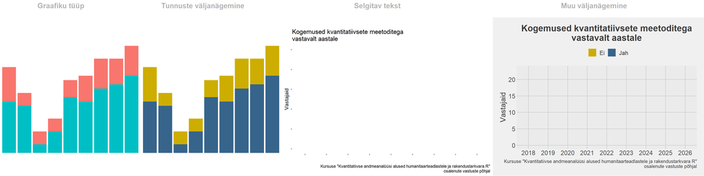

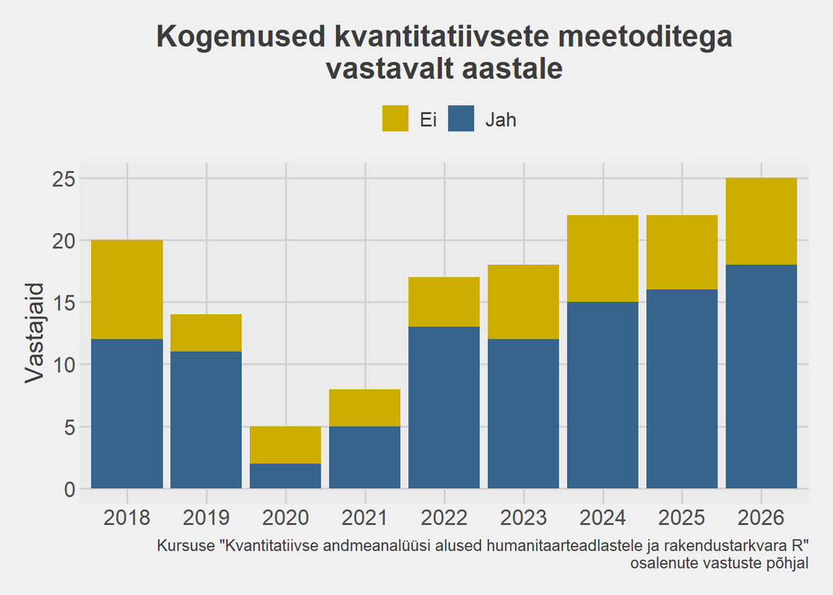

```r
# Esimesel korral tuleb pakett installida
# install.packages("ggplot2")

# Paketi kasutamiseks laadi pakett
library(ggplot2)
```

Ggploti spikri leiad [GitHubist](https://github.com/rstudio/cheatsheets/blob/master/data-visualization.pdf), levinumad funktsioonid ja rakendused lehelt [R Statistics](https://r-statistics.co/Top50-Ggplot2-Visualizations-MasterList-R-Code.html) või [R Charts](https://r-charts.com/ggplot2/).

Kasutame sel korral 2023. aasta riigikogu valimiste andmeid, mis on kraabitud lehelt https://rk2023.valimised.ee/et/detailed-voting-result/index.html. Lisaks oleme tabelisse lisanud kandidaatide vanuse, soo ja tähtkuju.

```r
# Laadi andmestik
# tabel on csv-formaadis, tabelil on päiserida tulpade nimedega (header),
# tulpasid eraldab tabulaator ("\t") ja faili kodeering on UTF-8
valimised <- read.delim("data/kandidaadid_2023.csv", header = T, sep = "\t", encoding = "UTF-8")
```

## ggploti graafikud ja esquisse()

Enne, kui hakkame ise ggploti graafikuid nullist ehitama, vaatame üht RStudio lisandmoodulit (*addin*) nimega [`esquisse`](https://dreamrs.github.io/esquisse/), mis võimaldab andmestikke ggplotiga visualiseerida interaktiivse kasutajaliidese abil, ilma koodi ise kirjutamata.

Lisandmooduliga saab

1. valida esmalt sobiva andmestiku, vaadata, milline see välja näeb, muuta tulbanimesid jm,
2. sikutada graafikule tunnused, mille jaotumist tahetakse visualiseerida,
3. muuta graafiku omadusi (värvid, sildid, teksti suurus jm),
4. kopeerida graafiku koodi ja/või salvestada graafik faili.

```r
# installime paketi
install.packages("esquisse")

# kasutame paketist 'esquisse' funktsiooni 'esquisser()'
esquisse::esquisser()

# sama saaksime teha ka tavaliselt paketti laadides ja seejärel funktsiooni kasutades
library(esquisse)
esquisser()
```

Mõtleme andmestikus olevate tunnuste tüüpidele ning püüame lisandmooduliga visualiseerida

1. kandidaatide **vanuse** jaotumist (kui vanad olid kandidaadid?)
2. kandidaatide **vanuse** jaotumist vastavalt **valimisnimekirjale** (kui vanad olid erinevate nimekirjade kandidaadid?)
3. kandidaatide **vanuse** jaotumist vastavalt **soole** (kas meeskandidaadid olid vanemad kui naiskandidaadid?)
4. kandidaatide **soo** jaotumist (kui palju oli mehi ja naisi?)
5. kandidaatide **soo** jaotumist vastavalt **valimisnimekirjale** (kas mõnes erakonnas oli rohkem naisi?)
6. kandidaatide **häältesaagi** jaotumist (kui palju hääli saadi?)
7. kandidaatide **häältesaagi** jaotumist vastavalt **valimisnimekirjale** (kui palju hääli said erinevate valimisnimekirjade kandidaadid?)
8. kandidaatide **häältesaagi** jaotumist vastavalt **vanusele** (kas vanemad/nooremad kandidaadid said rohkem hääli?)
9. kandidaatide **häältesaagi** jaotumist vastavalt **soole** (kas mehed/naised said rohkem hääli?)